# Exploratory

## Violence against women and girls (VAWG) is described by the United Nations as "one of the most serious, enduring, and devastating human rights violations in our world today."

- It expresses itself in a number of physical, sexual, and psychological ways, including:
- Battering, psychological bullying, marital rape, and femicide are forms of intimate partner violence.
- Rape, forced sexual acts, unwelcome sexual advances, child sexual exploitation, forced marriage, street harassment, stalking, and cyber-harassment are all forms of sexual assault and harassment.
- Slavery and sexual abuse are examples of human trafficking.
- genital mutilation in women;

### coloumns :

- Record
- Country
- Gender
- Demographics Question
- Demographics Response
- resons
- date
- Value
- year
- month
- day
- hour

```python
import numpy as np
import pandas as pd
import matplotlib.pyplot as plt
import seaborn as sb

%matplotlib inline
```

# Geathring Data :

```python
df = pd.read_csv('violence.csv')
```

```python
df.head(10)
```

|  | Record | Country | Gender | Demographics Question | Demographics Response | resons | date | Value |
| --- | --- | --- | --- | --- | --- | --- | --- | --- |
| 0 | 1 | Afghanistan | F | Marital status | Never married | ... if she burns the food | 1/1/2015 | NaN |
| 1 | 1 | Afghanistan | F | Education | Higher | ... if she burns the food | 1/1/2015 | 10.1 |
| 2 | 1 | Afghanistan | F | Education | Secondary | ... if she burns the food | 1/1/2015 | 13.7 |
| 3 | 1 | Afghanistan | F | Education | Primary | ... if she burns the food | 1/1/2015 | 13.8 |
| 4 | 1 | Afghanistan | F | Marital status | Widowed, divorced, separated | ... if she burns the food | 1/1/2015 | 13.8 |
| 5 | 1 | Afghanistan | F | Employment | Employed for kind | ... if she burns the food | 1/1/2015 | 17.0 |
| 6 | 1 | Afghanistan | F | Age | 15-24 | ... if she burns the food | 1/1/2015 | 17.3 |
| 7 | 1 | Afghanistan | F | Employment | Unemployed | ... if she burns the food | 1/1/2015 | 18.0 |
| 8 | 1 | Afghanistan | F | Residence | Rural | ... if she burns the food | 1/1/2015 | 18.1 |
| 9 | 1 | Afghanistan | F | Age | 25-34 | ... if she burns the food | 1/1/2015 | 18.2 |

# Assisst :

```python
for a,z in enumerate (df.columns):
    print (a+1, z)
```

[output not shown]

```python
df.info()
```

```
<class 'pandas.core.frame.DataFrame'>
RangeIndex: 12600 entries, 0 to 12599
Data columns (total 8 columns):
 #   Column                 Non-Null Count  Dtype
---  ------                 --------------  -----
 0   Record                 12600 non-null  int64
 1   Country                12600 non-null  object
 2   Gender                 12600 non-null  object
 3   Demographics Question  12600 non-null  object
 4   Demographics Response  12600 non-null  object
 5   resons                 12600 non-null  object
 6   date                   12600 non-null  object
 7   Value                  11187 non-null  float64
dtypes: float64(1), int64(1), object(6)
memory usage: 787.6+ KB
```

```python
df.shape
```

```
(12600, 8)
```

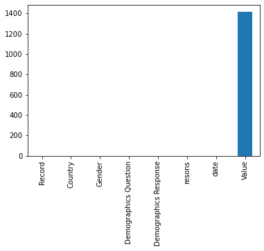

```python
df.isnull().sum().plot(kind = 'bar')
```

```python
df.count()
```

```
Record                   12600
Country                  12600
Gender                   12600
Demographics Question    12600
Demographics Response    12600
resons                   12600
date                     12600
Value                    11187
dtype: int64
```

```python
df.index
```

```
RangeIndex(start=0, stop=12600, step=1)
```

```python
df.columns
```

```
Index(['Record', 'Country', 'Gender', 'Demographics Question',
       'Demographics Response', 'resons', 'date', 'Value'],
      dtype='object')
```

```python
df.tail(10)
```

|  | Record | Country | Gender | Demographics Question | Demographics Response | resons | date | Value |
| --- | --- | --- | --- | --- | --- | --- | --- | --- |
| 12590 | 140 | Zimbabwe | M | Residence | Rural | ... if she argues with him | 1/1/2015 | 16.8 |
| 12591 | 140 | Zimbabwe | M | Residence | Urban | ... if she argues with him | 1/1/2015 | 8.8 |
| 12592 | 70 | Zimbabwe | M | Residence | Rural | ... if she burns the food | 1/1/2015 | 7.9 |
| 12593 | 70 | Zimbabwe | M | Residence | Urban | ... if she burns the food | 1/1/2015 | 2.3 |
| 12594 | 210 | Zimbabwe | M | Residence | Rural | ... if she goes out without telling him | 1/1/2015 | 21.0 |
| 12595 | 210 | Zimbabwe | M | Residence | Urban | ... if she goes out without telling him | 1/1/2015 | 11.8 |
| 12596 | 280 | Zimbabwe | M | Residence | Rural | ... if she neglects the children | 1/1/2015 | 20.1 |
| 12597 | 280 | Zimbabwe | M | Residence | Urban | ... if she neglects the children | 1/1/2015 | 15.0 |
| 12598 | 350 | Zimbabwe | M | Residence | Rural | ... if she refuses to have sex with him | 1/1/2015 | 7.2 |
| 12599 | 350 | Zimbabwe | M | Residence | Urban | ... if she refuses to have sex with him | 1/1/2015 | 3.7 |

```python
df.duplicated().sum()
```

```
0
```

# Data cleaning :

- so here we handle the date and some change to make more in analysis part

```python
df['date'] = pd.to_datetime(df.date)
```

```python
df['year'] = df.date.dt.year
df['month'] = df.date.dt.month_name()
df['day'] = df.date.dt.day_name()
df['hour'] = df.date.dt.hour
```

- Remove nan values

```python
df.dropna(inplace=True)
```

```python
df.isnull().sum()
```

```
Record                   0
Country                  0
Gender                   0
Demographics Question    0
Demographics Response    0
resons                   0
date                     0
Value                    0
year                     0
month                    0
day                      0
hour                     0
dtype: int64
```

- Great

# Exploratory :

- data visualization generally occurs during and after the data wrangling process, and is the main method that you will use to understand the patterns and relationships present in your data. This understanding will help you approach any statistical analyses and will help you build conclusions and findings. This process might also illuminate additional data cleaning tasks to be performed.
- t’s time to get to the interesting bits. Explore data and document findings .

### Univariate Exploration

- in this section , invistgate the dataset

```
array([[<matplotlib.axes._subplots.AxesSubplot object at 0x000002C149883400>,
      dtype=object)
```

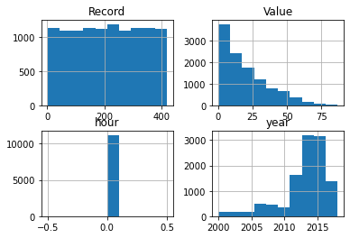

```python
df.hist()
```

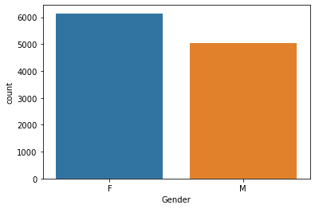

```python
sb.countplot(data= df , x ='Gender' )
```

- We find here that most of the communicators are women

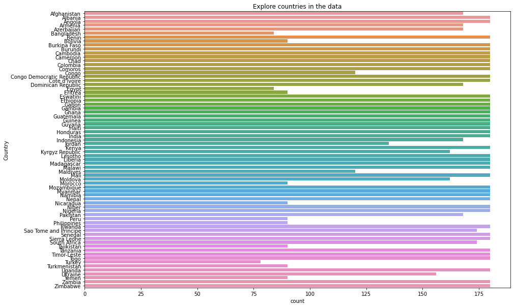

```python
plt.figure(figsize=(15, 10))
plt.title('Explore countries in the data')
sb.countplot(data= df , y ='Country'  );
```

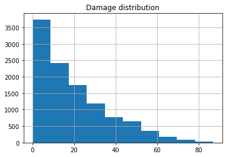

```python
df.Value.hist()
plt.title('Damage distribution')
```

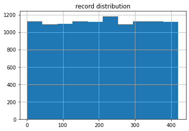

```python
df.Record.hist()
plt.title('record distribution')
```

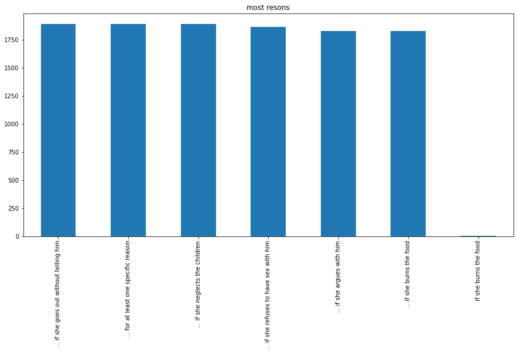

```python
df.resons.value_counts().plot(kind = 'bar' , figsize=(15,7));
plt.xticks(rotation=90);
plt.title('most resons')
```

- This is also an overview of most of the reasons that were mentioned here in the study, as we will find that violence may occur due to things such as refusing to have sex,so all resons is the same

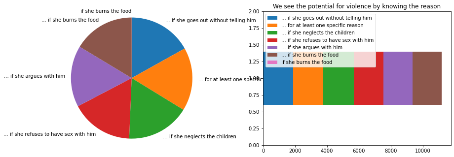

```python
sort = df['resons'].value_counts()
plt.figure(figsize = [15, 5])
plt.subplot(1, 2, 1)
plt.pie(sort, labels = sorted_counts.index, startangle = 90,
        counterclock = False);
plt.axis('square');
plt.subplot(1, 2, 2)
baseline = 0
for i in range(sort.shape[0]):
    plt.barh(y = 1, width = sort[i], left = baseline)
    baseline += sorted_counts[i]
plt.legend(sort.index)
plt.ylim([0,2])
plt.title('We see the potential for violence by knowing the reason');
```

## Bivariate Exploration :

- Plots representing the relationship between two variables measured on the given sample data. These plots help to identify the relationship pattern between the two variables.

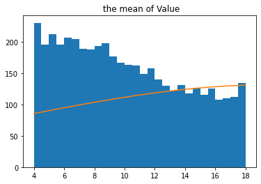

```python
# create a histogram of the data
bin_size = 0.5
bin_edges = np.arange(4, 18 + bin_size, bin_size)
plt.hist(data = df, x = 'Value', bins = bin_edges);

# overlay a theoretical normal distribution on top
samp_mean = df['Value'].mean()
samp_sd = df['Value'].std()

from scipy.stats import norm
x = np.linspace(4, 18, 200)
y = norm.pdf(x, samp_mean, samp_sd) # normal distribution heights
y *= df.shape[0] * bin_size # scale the distribution height

plt.plot(x, y)
plt.title(' the mean of Value')
```

- There might be cases where you are interested to see how closely your numeric data follows some hypothetical distribution. This might be important for certain parametric statistical tests, like checking for assumptions of normality

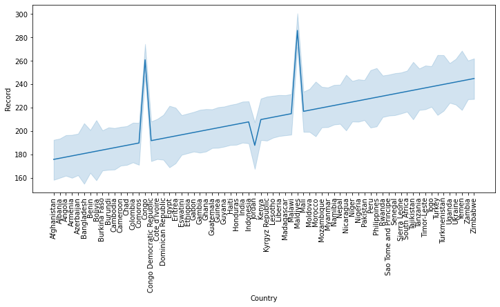

```python
plt.figure(figsize=(12, 5))
sb.lineplot(x=df['Country'], y=df['Record'], palette='winter')
plt.xticks(rotation=90);
```

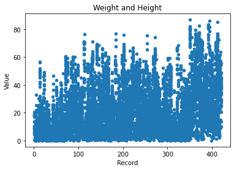

```python
df.plot(x='Record', y='Value', kind='scatter', title = 'Weight and Height');
```

```python
df.info()
```

```
<class 'pandas.core.frame.DataFrame'>
Int64Index: 11187 entries, 1 to 12599
Data columns (total 12 columns):
 #   Column                 Non-Null Count  Dtype
---  ------                 --------------  -----
 0   Record                 11187 non-null  int64
 1   Country                11187 non-null  object
 2   Gender                 11187 non-null  object
 3   Demographics Question  11187 non-null  object
 4   Demographics Response  11187 non-null  object
 5   resons                 11187 non-null  object
 6   date                   11187 non-null  datetime64[ns]
 7   Value                  11187 non-null  float64
 8   year                   11187 non-null  int64
 9   month                  11187 non-null  object
 10  day                    11187 non-null  object
 11  hour                   11187 non-null  int64
dtypes: datetime64[ns](1), float64(1), int64(3), object(7)
memory usage: 1.4+ MB
```

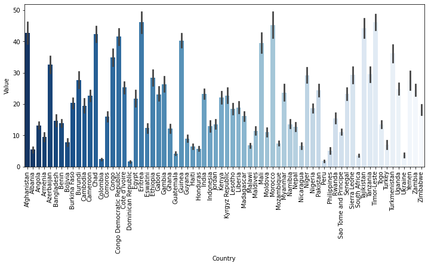

```python
plt.figure(figsize=(12, 5))
sb.barplot(x=df['Country'], y=df['Value'], palette='Blues_r')
plt.xticks(rotation=90);
```

- When looking at the amount of damage between countries in general in that data, we find that Eritrea is the most harmful to women in violence, and Peru and Ukraine are the least harmful. I know that this study did not tour the first world countries significantly, but here we focus in that study on the countries in which the quantity is located. A great deal of violence against women

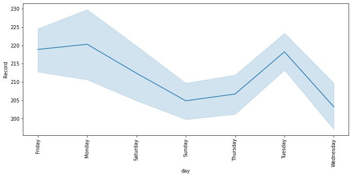

```python
plt.figure(figsize=(12, 5))
sb.lineplot(x=df['day'], y=df['Record'], palette='Blues_r')
plt.xticks(rotation=90);
```

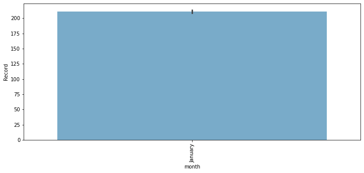

```python
plt.figure(figsize=(12, 5))
sb.barplot(x=df['month'], y=df['Record'], palette='Blues_r')
plt.xticks(rotation=90);
```

- and here we see that this study was created at january every year

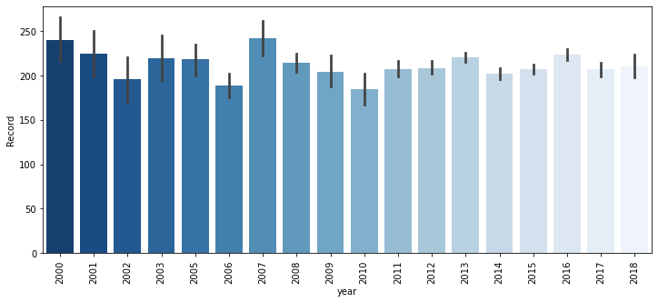

```python
plt.figure(figsize=(12, 5))
sb.barplot(x=df['year'], y=df['Record'], palette='Blues_r')
plt.xticks(rotation=90);
```

# Multivariate Exploration:

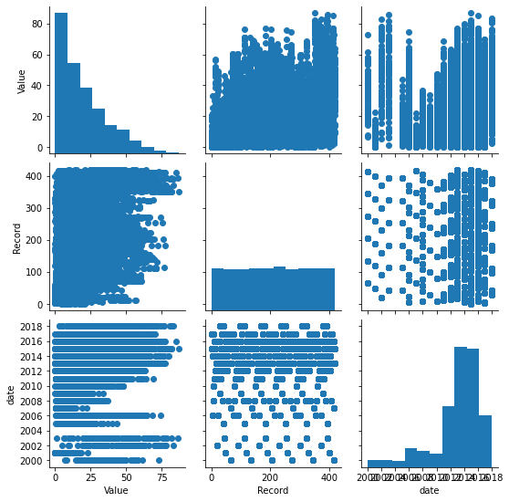

```python
g = sb.PairGrid(data = df, vars = ['Value', 'Record', 'date'])
g.map_diag(plt.hist)
g.map_offdiag(plt.scatter)
plt.xticks(rotation=90);
```

- over view on our dataset

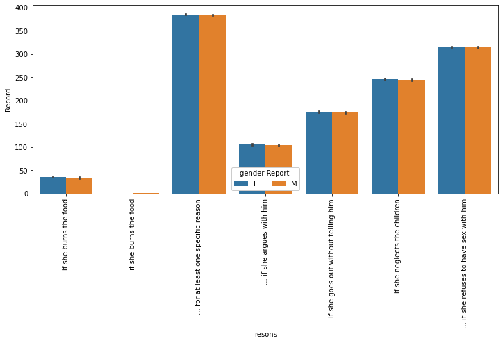

```python
plt.figure(figsize=(12, 5))

ax = sb.barplot(data = df, x = 'resons', y = 'Record', hue = 'Gender')
ax.legend(loc = 8, ncol = 3, framealpha = 1, title = 'gender Report ')
plt.xticks(rotation=90);
```

- There is almost equal gender in this survey, although women are slightly more than men

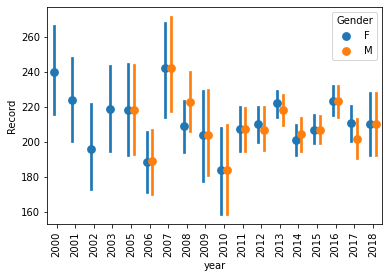

```python
ax = sb.pointplot(data = df, x = 'year', y = 'Record', hue = 'Gender',
                  dodge = 0.3, linestyles = "")
plt.xticks(rotation=90);
```

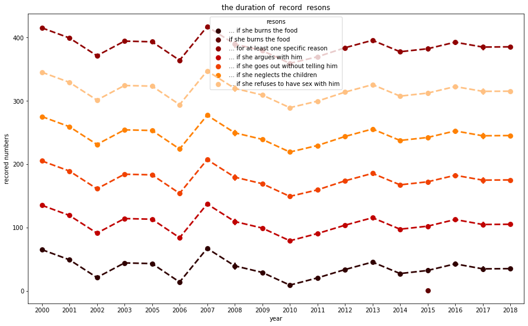

```python
plt.subplots(figsize = (15,9))
ax = sb.pointplot(data = df, x = 'year', y = 'Record', hue = 'resons',palette = 'gist_heat', linestyles = '--')
plt.title('the duration of  record  resons')
plt.ylabel('recored numbers')
ax.set_yticklabels([],minor = True);
```

- In this weighting, we find there are different results, whether in the year or during the year or between the year, for example, 2007 is considered one of the most harmful years related to the causes that were taken to complete violence against women

# Explanatory :

- data visualization techniques are used after generating your findings, and are used to help communicate your results to others. Understanding design considerations will make sure that your message is clear and effective. In addition to being a good producer of visualizations, going through this project will also help you be a good consumer of visualizations that are presented to you by others.

# This Analysis About the most case that have record 400 or haigher cases :

```python
 df2 = df[df['Record']  >=400]
```

```python
df2.head(100)
```

|  | Record | Country | Gender | Demographics Question | Demographics Response | resons | date | Value | year | month | day | hour |
| --- | --- | --- | --- | --- | --- | --- | --- | --- | --- | --- | --- | --- |
| 8820 | 400 | Niger | F | Age | 15-24 | ... for at least one specific reason | 2012-01-01 | 57.5 | 2012 | January | Sunday | 0 |
| 8821 | 400 | Niger | F | Age | 25-34 | ... for at least one specific reason | 2012-01-01 | 61.0 | 2012 | January | Sunday | 0 |
| 8822 | 400 | Niger | F | Age | 35-49 | ... for at least one specific reason | 2012-01-01 | 60.2 | 2012 | January | Sunday | 0 |
| 8838 | 400 | Niger | F | Education | Higher | ... for at least one specific reason | 2012-01-01 | 17.6 | 2012 | January | Sunday | 0 |
| 8839 | 400 | Niger | F | Education | No education | ... for at least one specific reason | 2012-01-01 | 60.1 | 2012 | January | Sunday | 0 |
| ... | ... | ... | ... | ... | ... | ... | ... | ... | ... | ... | ... | ... |
| 9402 | 403 | Peru | F | Employment | Employed for cash | ... for at least one specific reason | 2012-01-01 | 3.2 | 2012 | January | Sunday | 0 |
| 9403 | 403 | Peru | F | Employment | Employed for kind | ... for at least one specific reason | 2012-01-01 | 6.9 | 2012 | January | Sunday | 0 |
| 9404 | 403 | Peru | F | Employment | Unemployed | ... for at least one specific reason | 2012-01-01 | 2.8 | 2012 | January | Sunday | 0 |
| 9420 | 403 | Peru | F | Marital status | Married or living together | ... for at least one specific reason | 2012-01-01 | 3.5 | 2012 | January | Sunday | 0 |
| 9421 | 403 | Peru | F | Marital status | Never married | ... for at least one specific reason | 2012-01-01 | 3.4 | 2012 | January | Sunday | 0 |

100 rows × 12 columns

```python
df2.info()
```

```
<class 'pandas.core.frame.DataFrame'>
Int64Index: 530 entries, 8820 to 12589
Data columns (total 12 columns):
 #   Column                 Non-Null Count  Dtype
---  ------                 --------------  -----
 0   Record                 530 non-null    int64
 1   Country                530 non-null    object
 2   Gender                 530 non-null    object
 3   Demographics Question  530 non-null    object
 4   Demographics Response  530 non-null    object
 5   resons                 530 non-null    object
 6   date                   530 non-null    datetime64[ns]
 7   Value                  530 non-null    float64
 8   year                   530 non-null    int64
 9   month                  530 non-null    object
 10  day                    530 non-null    object
 11  hour                   530 non-null    int64
dtypes: datetime64[ns](1), float64(1), int64(3), object(7)
memory usage: 53.8+ KB
```

```python
df2.shape
```

```
(530, 12)
```

```python
base_color = sb.color_palette()[0]
```

- We find here that the most affected are women, and we also find the slight difference in that small sample, where reports are greater or equal 400 cases

## Most of the two sexes participated in the study

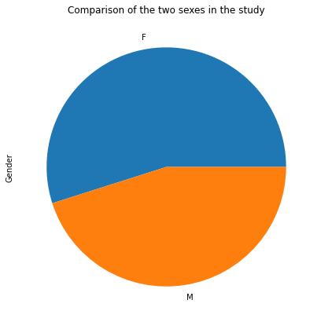

```python
plt.figure(figsize = [10,7])
plt.title('Comparison of the two sexes in the study')

df.Gender.value_counts().plot(kind = 'pie');
```

## Most of the years that were mentioned in the report, violence against women in the reports that exceed 400 cases

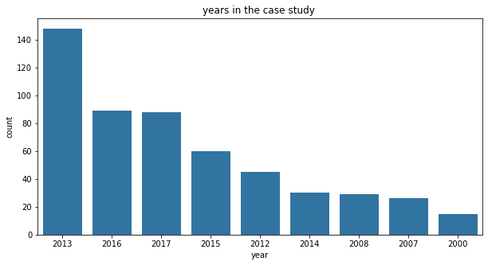

```python
plt.figure(figsize = [10,5])
plt.title('years in the case study ')

sb.countplot(data= df2 , x = 'year' , color = base_color , order = order_type);
```

- and here 2013 is the most year have record and more value

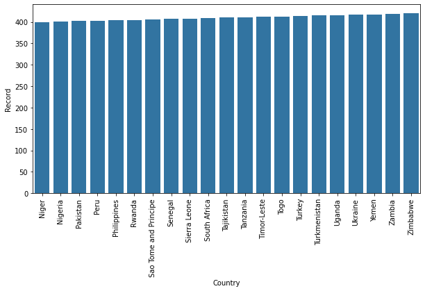

```python
plt.figure(figsize = [10,5])

ax = sb.barplot(data = df2, x = 'Country', y = 'Record', color = base_color);
plt.xticks(rotation=90);
```

- And unexpectedly, we see Peru, although it is the least in terms of harm to women, but it has many complaints, and we find that the largest country with complaints is Zimbaway

```python
order_type =  df2['year'].value_counts().index
```

## Most harmful countries and reports against violence

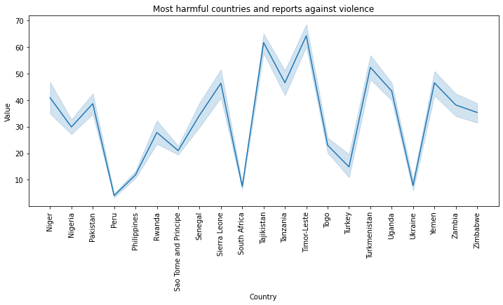

```python
plt.figure(figsize=(12, 5))
plt.title('Most harmful countries and reports against violence')

sb.lineplot(x=df2['Country'], y=df['Value'], palette='winter')
plt.xticks(rotation=90);
```

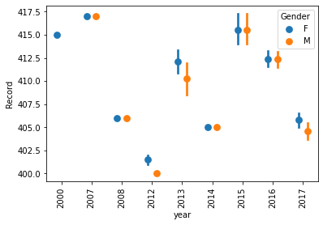

```python
ax = sb.pointplot(data = df2, x = 'year', y = 'Record', hue = 'Gender',
                  dodge = 0.3, linestyles = "")
plt.xticks(rotation=90);
```

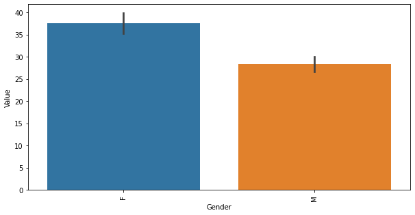

```python
plt.figure(figsize = [10,5])

ax = sb.barplot(data = df2, x = 'Gender', y = 'Value');
plt.xticks(rotation=90);
```

- here we can see female is most gender

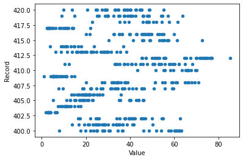

```python
df2.plot(x='Value' , y='Record' , kind= 'scatter' )
```

- I don't think there is a clear relationship to this graphic

## This analysis about Egypt :

```python
Egypt = df[df['Country']  == 'Egypt']
```

```python
Egypt.head(10)
```

|  | Record | Country | Gender | Demographics Question | Demographics Response | resons | date | Value | year | month | day | hour |
| --- | --- | --- | --- | --- | --- | --- | --- | --- | --- | --- | --- | --- |
| 3421 | 20 | Egypt | F | Education | Higher | ... if she burns the food | 2014-01-01 | 1.1 | 2014 | January | Wednesday | 0 |
| 3422 | 20 | Egypt | F | Residence | Urban | ... if she burns the food | 2014-01-01 | 3.2 | 2014 | January | Wednesday | 0 |
| 3423 | 20 | Egypt | F | Employment | Employed for cash | ... if she burns the food | 2014-01-01 | 4.4 | 2014 | January | Wednesday | 0 |
| 3424 | 20 | Egypt | F | Education | Secondary | ... if she burns the food | 2014-01-01 | 4.9 | 2014 | January | Wednesday | 0 |
| 3425 | 20 | Egypt | F | Age | 25-34 | ... if she burns the food | 2014-01-01 | 6.5 | 2014 | January | Wednesday | 0 |
| 3426 | 20 | Egypt | F | Marital status | Married or living together | ... if she burns the food | 2014-01-01 | 6.9 | 2014 | January | Wednesday | 0 |
| 3427 | 20 | Egypt | F | Employment | Unemployed | ... if she burns the food | 2014-01-01 | 7.1 | 2014 | January | Wednesday | 0 |
| 3428 | 20 | Egypt | F | Age | 15-24 | ... if she burns the food | 2014-01-01 | 7.3 | 2014 | January | Wednesday | 0 |
| 3429 | 20 | Egypt | F | Age | 35-49 | ... if she burns the food | 2014-01-01 | 7.3 | 2014 | January | Wednesday | 0 |
| 3430 | 20 | Egypt | F | Marital status | Widowed, divorced, separated | ... if she burns the food | 2014-01-01 | 8.1 | 2014 | January | Wednesday | 0 |

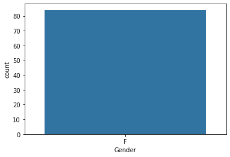

```python
sb.countplot(data= Egypt , x = 'Gender' )
```

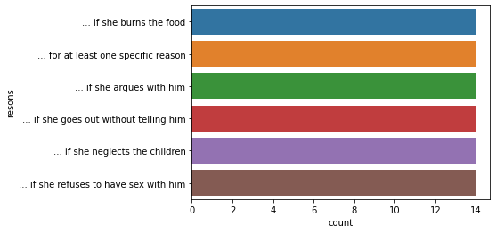

```python
sb.countplot(data= Egypt , y = 'resons' )
```

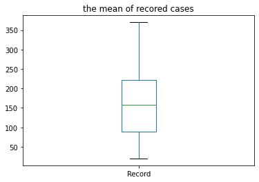

```python
plt.title('the mean of recored cases')

Egypt.Record.describe().plot(kind = 'box' )
```